# ETC3250/5250 Introduction to Machine Learning

Week 6: Neural networks and deep learning

Jack Jewson

Jack.Jewson@monash.edu

Department of Econometrics and Business Statistics

## Overview

We will cover:

- Structure of a neural network
- Fitting neural networks
- Diagnosing the fit

## Structure of a neural network

## Linear regression as a network

Consider a linear regression model regressing a continuous response $y\in \mathbb{R}$, on predictors $x\in\mathbb{R}^p$

$$\widehat{y} = \mathbb{E}[y\mid x] = \beta_0 + \sum_{j=1}^p\beta_jx_j$$

We can draw this as a network model:

- $p$ inputs (predictors),
- multiplied by weights (coefficients),
- summed, add a constant,
- predicts output (response).

## Difference between linear and logistic regression

Logistic regression, predicting the probability of a binary outcome ,
$$P(Y = 1) = \frac{1}{1+e^{-(\beta_0+\sum_{j=1}^p\beta_jx_j)}}$$

Can also be written as a network model

- $p$ inputs (predictors),
- multiplied by weights (coefficients),
- summed, add a constant,
- Applied a function to this in order to model a probability
- predicts output (response).

## Neural Network Notation

Both linear and logistic regression are **simple** one layered neural networks

- Inputs Layer where the predictors are fed in,
- Output Layer where the predicted value from the model is fed out
- The connection between any node $j$ in the input layer and node $k$ in the output layer is weighted by a parameter $b_{jk}$,
- Nodes which take the weighted sum of their inputs $\sum_{j=1}^pb_{jk}x_j$ add a bias $b_{0k}$ and return a function applied to this

## Neural Network Notation

Both linear and logistic regression are **simple** neural networks

- These NNs only have one node and its an output node, so it uses an output function $\sigma(\cdot)$.
  - In Linear regression $\sigma(a) = a$
  - In Logistic regression $\sigma(a) = \frac{1}{1+e^{-a}}$

## Hidden layers

So neural networks are just simple linear models? **Absolutely not**

- Introduce a Hidden Layer between the inputs (predictors) and outputs (the machine learning model prediction),
- Each node in the hidden layer takes the weighted sum of the inputs $\sum_{j=1}^pb_{jk}x_j$ add a bias $b_{0k}$ and return a function applied to this
- For hidden layers this function is called an activation function $\phi(\cdot)$.
  - This must be a non-linear function (as every other part of the NN is linear)

## Single hidden layer NN

Consider $s$ hidden nodes in a single hidden layer

- Every input node is connected to every hidden node - with weight $b_{jk}$ $j = 1,\ldots p$, $k = 1,\ldots, s$
- Every hidden node is connected to every output node with weight $a_{jk}$ $j = 1,\ldots s$ $k = 1$
- The output of each hidden node is $h_k = \phi(b_{0k} + \sum_{j=1}^pb_{jk}x_j)$
- The machine learning model prediction is $\sigma(a_{01} + \sum_{j=1}^sa_{j1}h_j)$

## Single hidden layer NN

Consider $s$ hidden nodes in a single hidden layer

$$\begin{align}
g(&y; x) = \\
&\sigma(a_{01} + \sum_{k=1}^sa_{k1}\phi(b_{0k} + \sum_{j=1}^pb_{jk}x_j))
\end{align}$$

This is referred to as a fully connected feed forward neural network with 1 hidden layer (sometimes referred to as having 2 layers)

## Feature Engineering

The hidden layers are learning features, i.e. combinations of the predictor variables, that best predict the response

Logistic regression

$$P(Y= 1\mid x) = \frac{1}{1+e^{-x^\top\beta}}$$

- $x \in \mathbb{R}^p$ are predictor variables
- $\beta\in\mathbb{R}^p$ regression coefficients

Single Hidden Layer NN

$$P(Y= 1\mid x) = \frac{1}{1+e^{-h^\top a}}$$

- $h \in \mathbb{R}^s$ are hidden layer outputs $h_k = \phi(b_{0k} + \sum_{j=1}^pb_{jk}x_j)$
- with parameters $b$
- $a\in\mathbb{R}^p$ coefficients that connect the encoing of the predictors with the response
- Can view $h$ as your transformed features that were learned to best predict $y$ from $x$

## Activation functions

- The output function $\sigma(\cdot)$ is given by the problem
- The activation function is part of the model’s architecture
- The activation function **MUST** be non-linear - a NN with linear activation functions would just be an overparametrised linear model
- Popular examples are
  - $\tanh(x) = \frac{e^x - e^{-x}}{e^x + e^{-x}}$
  - $ReLU(x) = \max(0, x)$

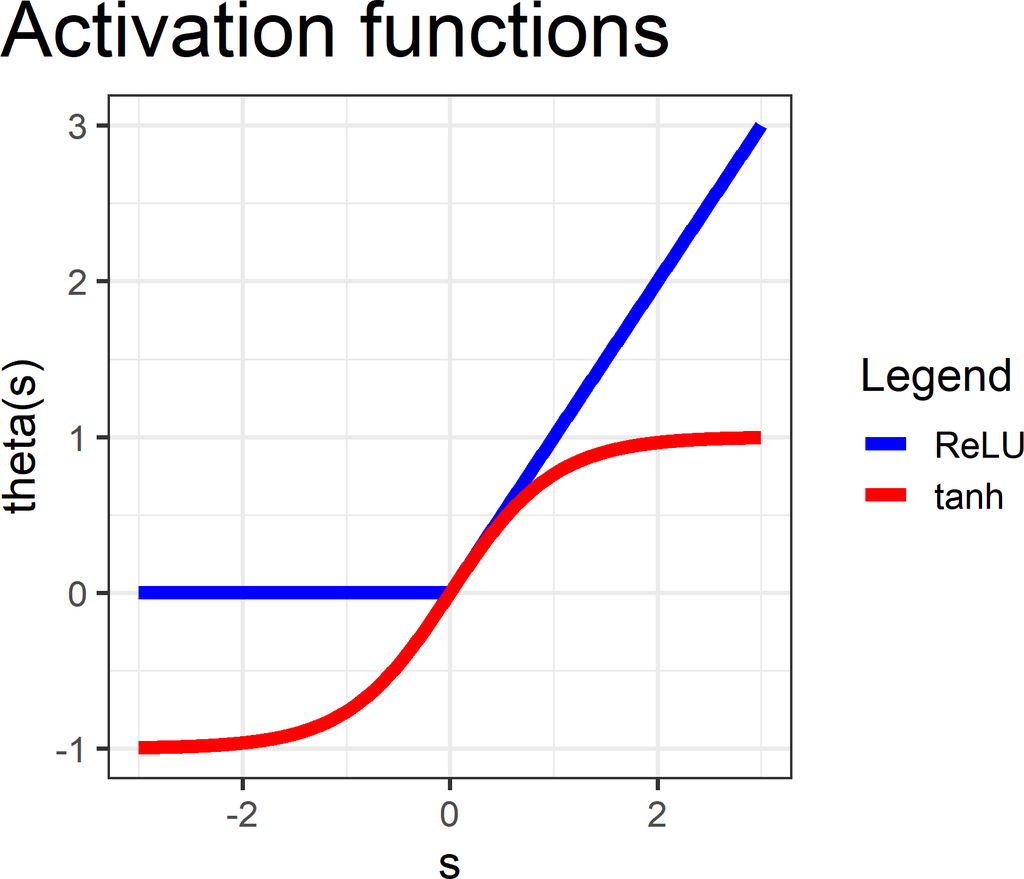

## What does this look like? (1/2)

The architecture allows for combining multiple linear models to generate non-linear classifications.

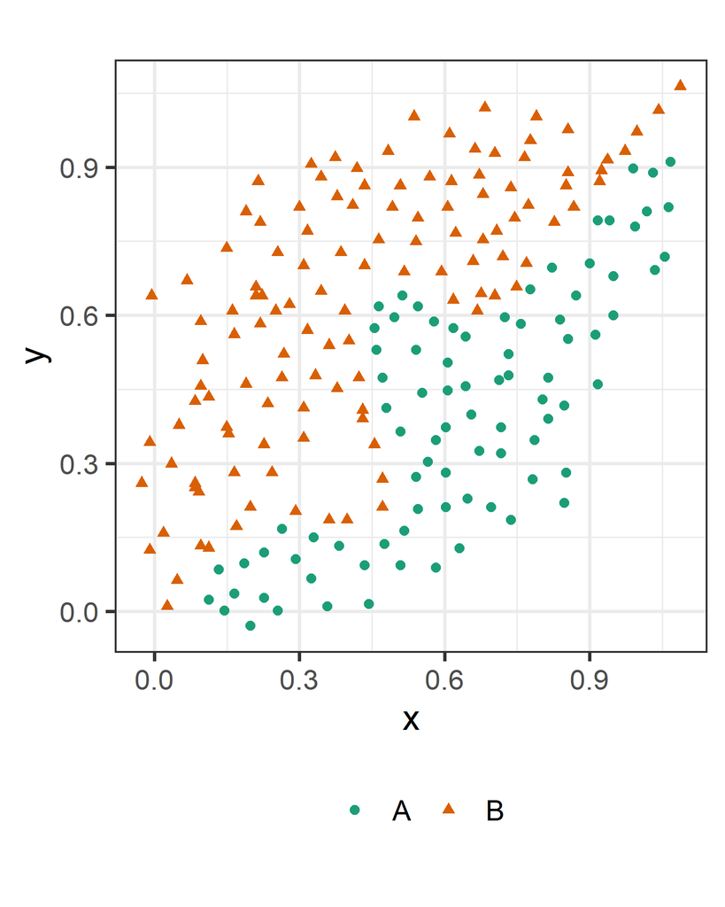

The best fit uses $s=4$, four nodes in the hidden layer. Can you sketch four lines that would split this data well?

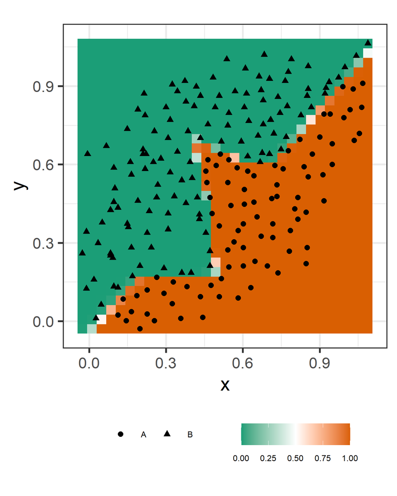

[Wickham et al (2015) Removing the Blindfold](http://onlinelibrary.wiley.com/doi/10.1002/sam.11271/abstract)

## What does this look like? (2/2)

The models at each of the nodes of the hidden layer. Plotting $h_j$.

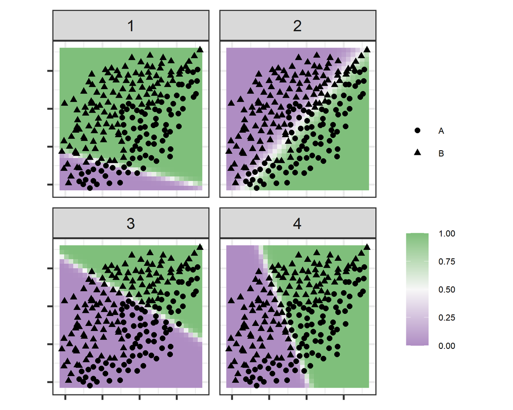

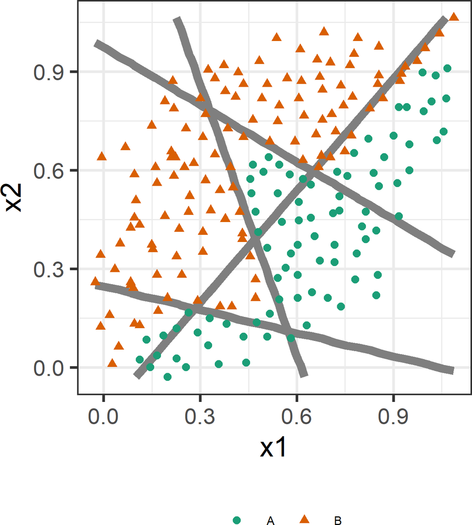

The parameters $a$ of the connection between the hidden layer and the output layer learn how to combine these 4 ‘*models*’ into one prediction

## Model fitting

The Neural Network architecture defines the number of hidden layers, the number of nodes in each layer and the activation functions. These are the NN hyperparameters.

For fixed architecture (#Hidden Layers = 1, #Nodes = $s$), fitting the model requires learning the best values for parameters $b_0 \in\mathbb{R}^s$, $B\in\mathbb{R}^{p, s}$ (with elements $b_{jk}$), $a_0\in\mathbb{R}$, and $a\in\mathbb{R}^s$

These are all just numbers! We learn them exactly how we learned the regression parameters in linear models, using Maximum Likelihood

## Model fitting

**Linear Models**

- Linear Regression:
  - $E[Y\mid x] = \beta_0 + \sum_{j=1}^px_j\beta_j$
  - $\beta$’s learned via least squares
- Logistic Regression:
  - $P(Y = 1\mid x) = \frac{1}{1+e^{-\beta_0 - \sum_{j=1}^px_j\beta_j}}$
  - $\beta$’s learned via MLE

## Model fitting

**Single Layer Neural Network**

- Regression:
  - $E[Y\mid x] = a_{01} + \sum_{k=1}^sa_{k1}\phi(b_{0k} + \sum_{j=1}^pb_{jk}x_j)$
  - Learn $a$’s and $b$’s to minimise the squared error
- Binary Classification:
  - $P(Y = 1\mid x) = \frac{1}{1+e^{-a_{01} - \sum_{k=1}^sa_{k1}\phi(b_{0k} + \sum_{j=1}^pb_{jk}x_j)}}$
  - Learn $a$’s and $b$’s that make the observed data the most likely

## Model fitting

There is one key difference in how linear models and neural networks are fit.

In linear models the exact MLE is found. If you fit the model twice you get exactly the same fit.

In Neural Network models the MLE is not found exactly. If you fit the model twice you will get a different fit.

This is a result of NN’s having many more parameters and as a resault being much more complicated prediction functions

- The linear models have $p+1$ parameters.
- The Single Hidden Layer NN has $(p+1)\times s + (s+1)$

## But can be painful to find the best!

The same models with $s=2, 3, 4$ fit several times.

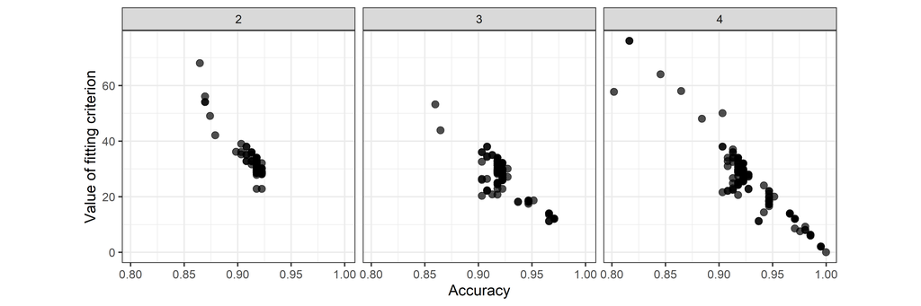

Fitted using the R package `nnet`. It’s very unstable, and this is still a problem with current procedures.

## Fitting with keras

## Steps (1/2)

1. Define architecture
- How many hidden layers do you need?
- How many nodes in the hidden layer?
2. Specify activation function: relu (rectified linear unit) or tanh, and output function linear, sigmoid, softmax
3. Choose loss function:
- MSE: squared difference between observation and prediction (also the log-likleihood under the Gaussian distribution)
- cross-entropy: fancy name for the log-likelihood of binary regression

## Steps (2/2)

4. Training process:
- epochs: number of times the algorithm sees the entire data set
- batch_size: subset used at each iteration
- validation_split: proportion for hold-out set for computing error rate (a mini testing set)
5. Evaluation:
- usual metrics: accuracy, ROC, AUC (area under ROC curve), confusion table
- visualise the predictive probabilities
- examine misclassifications
- examine specific nodes, to understand what part it plays
- examine model boundary relative to the observed data

## Example: penguins (1/5)

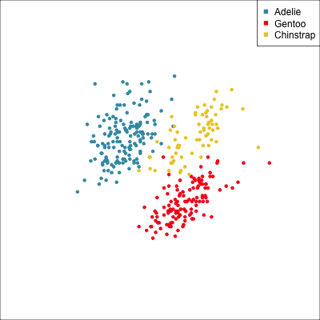

- 4D data
- Simple cluster structure to classes
- How many nodes in the hidden layer?

Choose 2 nodes, because reducing to 2D, makes for easy classification.